# Identification of cell populations

#### k-means

This approach assumes a pre-determined number of round equally-sized clusters.

The dendogram built above suggests there may be 6 populations.

Let's define 6 clusters.

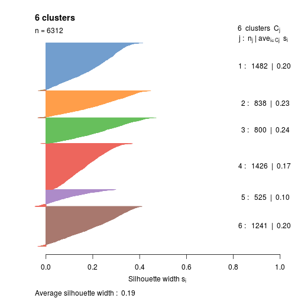

```r
kclust <- kmeans(pcs, centers=6)

# compute silhouette
require("cluster")
sil <- silhouette(kclust$cluster, dist(pcs))

# plot silhouette:
clust.col <- scater:::.get_palette("tableau10medium") # hidden scater colours
sil.cols <- clust.col[ifelse(sil[,3] > 0, sil[,1], sil[,2])]
sil.cols <- sil.cols[order(-sil[,1], sil[,3])]
plot(sil, main = paste(length(unique(kclust$cluster)), "clusters"),
    border=sil.cols, col=sil.cols, do.col.sort=FALSE)
```

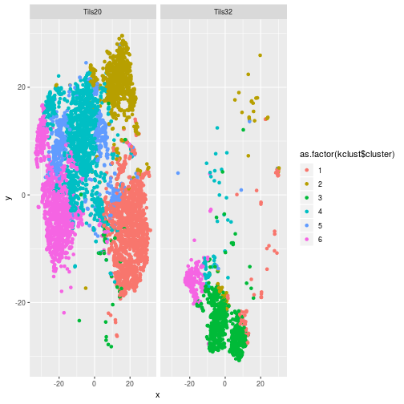

```r
tSneCoord <- as.data.frame(reducedDim(nz.sce, "TSNE"))
colnames(tSneCoord) <- c("x", "y")
p2 <- ggplot(tSneCoord, aes(x, y)) +
    geom_point(aes(color = as.factor(kclust$cluster)))
p2 + facet_wrap(~ nz.sce$Sample2)
```

To find the most appropriate number of clusters, one performs the analysis for a series of k, computes a measure of fit of cluster defined: the within clusteer sum-of-square. This value descreases as k increases, by an amount that decreases with k. Choose k a the inflexion point of the curve.

```r
library(broom)
require(tibble)
require(dplyr)
require(tidyr)
library(purrr)
points <- as.tibble(pcs)
augment(kclust, points)
```

```
## # A tibble: 6,312 x 11
##        PC1    PC2   PC3    PC4    PC5    PC6    PC7     PC8    PC9   PC10
##      <dbl>  <dbl> <dbl>  <dbl>  <dbl>  <dbl>  <dbl>   <dbl>  <dbl>  <dbl>
##  1  -9.81   3.10   4.41 -2.06  -0.261  5.35   2.11  -0.0529 -0.127  0.679
##  2  -5.84   2.85  -3.91  1.16  -1.06   0.243  0.458 -1.71   -1.16   1.49
##  3   7.44  -0.530  3.19  4.14   3.84  -1.29  -0.253 -1.59    0.364  0.616
##  4   8.10   4.32   1.47  0.580  1.61  -1.00  -2.96   0.473   3.52  -2.23
##  5  10.2   -5.07   3.72  5.29   3.53  -1.13  -1.09  -1.74    1.66  -0.937
##  6  -3.31  -1.17   2.24  0.947 -0.721 -2.56   4.19  -0.327  -2.09   0.119
##  7  -6.89   2.15  -5.07  7.30   3.48   0.596  0.549 -4.43    2.85   1.30
##  8  -8.36   2.23  -5.11  3.50   2.86  -4.21  -0.729 -2.97   -0.377 -0.173
##  9  -9.19  -5.97   3.60  0.162 -1.89   1.33  -0.446 -0.423   1.53  -1.49
## 10   0.489  2.61   2.03  1.79  -2.61   0.334 -0.393 -1.50   -0.381 -0.535
## # ... with 6,302 more rows, and 1 more variable: .cluster <fct>
```

```r
kclusts <- tibble(k = 1:9) %>%
  mutate(
    kclust = map(k, ~kmeans(points, .x)),
    tidied = map(kclust, tidy),
    glanced = map(kclust, glance),
    augmented = map(kclust, augment, points)
  )

kclusts
```

```
## # A tibble: 9 x 5
##       k kclust       tidied           glanced         augmented
##   <int> <list>       <list>           <list>          <list>
## 1     1 <S3: kmeans> <tibble [1 × 13… <tibble [1 × 4… <tibble [6,312 × 11…
## 2     2 <S3: kmeans> <tibble [2 × 13… <tibble [1 × 4… <tibble [6,312 × 11…
## 3     3 <S3: kmeans> <tibble [3 × 13… <tibble [1 × 4… <tibble [6,312 × 11…
## 4     4 <S3: kmeans> <tibble [4 × 13… <tibble [1 × 4… <tibble [6,312 × 11…
## 5     5 <S3: kmeans> <tibble [5 × 13… <tibble [1 × 4… <tibble [6,312 × 11…
## 6     6 <S3: kmeans> <tibble [6 × 13… <tibble [1 × 4… <tibble [6,312 × 11…
## 7     7 <S3: kmeans> <tibble [7 × 13… <tibble [1 × 4… <tibble [6,312 × 11…
## 8     8 <S3: kmeans> <tibble [8 × 13… <tibble [1 × 4… <tibble [6,312 × 11…
## 9     9 <S3: kmeans> <tibble [9 × 13… <tibble [1 × 4… <tibble [6,312 × 11…
```

```r
clusters <- kclusts %>%
  unnest(tidied)
assignments <- kclusts %>%
  unnest(augmented)
clusterings <- kclusts %>%
  unnest(glanced, .drop = TRUE)
```

Plot the total wihtin cluster sum-of-squares and decide on k.

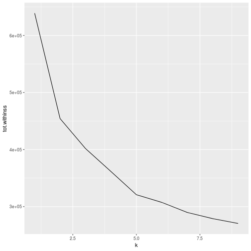

```r
ggplot(clusterings, aes(k, tot.withinss)) +
  geom_line()
```

Check silhouette for a k of 5.

Copy the cluster assignment to the SCE object.

```r
df <- as.data.frame(assignments)
nz.sce$kmeans5 <- as.numeric(df[df$k == 5, ".cluster"])
```

Check silhouette.

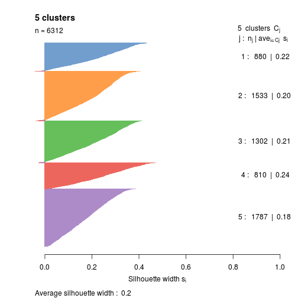

```r
library(cluster)
clust.col <- scater:::.get_palette("tableau10medium") # hidden scater colours
sil <- silhouette(nz.sce$kmeans5, dist = my.dist)
sil.cols <- clust.col[ifelse(sil[,3] > 0, sil[,1], sil[,2])]
sil.cols <- sil.cols[order(-sil[,1], sil[,3])]
plot(sil, main = paste(length(unique(nz.sce$kmeans5)), "clusters"),
    border=sil.cols, col=sil.cols, do.col.sort=FALSE)
```

#### graph-based clustering

Let's build a shared nearest-neighbour graph using cells as nodes, then perform community-based clustering.

Build graph, define clusters, check membership across samples, show membership on t-SNE.

```r
#buildSNNGraph(x, ..., subset.row=NULL, assay.type="logcounts",  get.spikes=FALSE, use.dimred=NULL)
snn.gr <- buildSNNGraph(nz.sce, use.dimred="PCA")
cluster.out <- igraph::cluster_walktrap(snn.gr)
my.clusters <- cluster.out$membership
table(my.clusters)
```

```
## my.clusters
##    1    2    3    4    5    6    7    8    9   10   11   12   13   14
##  528 1411  807  629  333  258  340  852  482  387  126   45   27   87
```

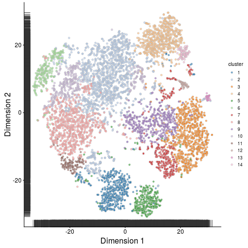

```r
nz.sce$cluster <- factor(my.clusters)
plotTSNE(nz.sce, colour_by="cluster") + fontsize
```

Check silhouette:

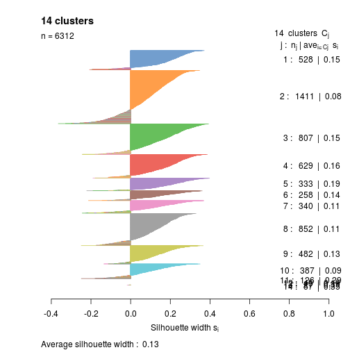

```r
require(cluster)
clust.col <- scater:::.get_palette("tableau10medium") # hidden scater colours
sil <- silhouette(my.clusters, dist(reducedDim(nz.sce, "PCA")))
sil.cols <- clust.col[ifelse(sil[,3] > 0, sil[,1], sil[,2])]
sil.cols <- sil.cols[order(-sil[,1], sil[,3])]
plot(sil, main = paste(length(unique(my.clusters)), "clusters"),
    border=sil.cols, col=sil.cols, do.col.sort=FALSE)
```

Show similarity between clusters on a network.

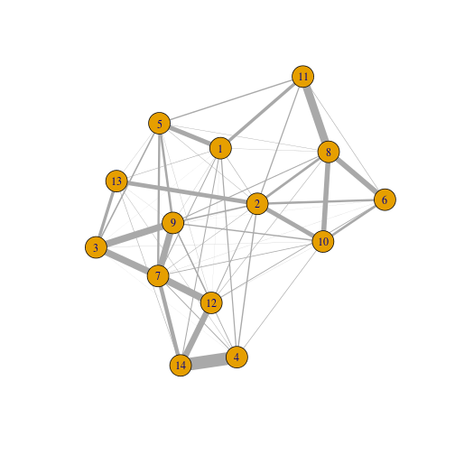

```r
cluster.gr <- igraph::graph_from_adjacency_matrix(ratio,
    mode="undirected", weighted=TRUE, diag=FALSE)
plot(cluster.gr, edge.width=igraph::E(cluster.gr)$weight*10)
```

### Detecting genes differentially expressed between clusters

#### Differential expression analysis

```r
markers <- findMarkers(nz.sce, my.clusters)
```

Results are compiled in a single table per cluster taht stores the outcome of comparisons against other cluster. One can then select differentially expressed genes from each pairwise comparison between clusters.

Let's define a set of genes for cluster 1 by selecting the top 10 genes of each comparison, and check test output, eg adjusted p-values and log-fold changes.

```r
marker.set <- markers[["1"]]
head(marker.set, 10)
```

```
## DataFrame with 10 rows and 15 columns
##                       Top                   FDR            logFC.2
##                 <integer>             <numeric>          <numeric>
## ENSG00000111640         1  1.7541887443221e-234   1.86975856304341
## ENSG00000164587         1 2.51998973124285e-231 -0.675828388114791
## ENSG00000115738         1 1.48019344546987e-230    1.8096701918672
## ENSG00000235576         1 5.28833894528471e-202   1.82200756032717
## ENSG00000265681         1 3.65931690443043e-200   1.24811241564453
## ENSG00000100453         1 4.39203627867515e-132    1.8688277408241
## ENSG00000186891         1 9.09897634571558e-123   1.35495648256636
## ENSG00000174021         1 3.24321731924953e-103  0.309926764023462
## ENSG00000121966         2 7.71741184168024e-209  -1.53056051296443
## ENSG00000169442         2 4.20550202945563e-201   0.14405498841732
##                             logFC.3            logFC.4             logFC.5
##                           <numeric>          <numeric>           <numeric>
## ENSG00000111640   0.491583590140298  0.678055897699035   0.117933177633428
## ENSG00000164587    0.32785630654531 0.0468902175979005  -0.109742336499087
## ENSG00000115738    1.86515471569221    0.8467760087531    1.40285021465344
## ENSG00000235576    2.09919844706494   1.43136802019798    1.94744125580695
## ENSG00000265681    1.55850394362501   1.51906776252401 -0.0495945451498021
## ENSG00000100453    2.10636294865398  0.186936656023702    1.62762515343913
## ENSG00000186891  -0.145890585724069   1.35504904521897  -0.390130305394427
## ENSG00000174021 -0.0960777990024363  0.135577749368252  0.0574521332926199
## ENSG00000121966 -0.0196297705455049 -0.309069038292081 -0.0211549512041935
## ENSG00000169442    1.77963982828955   1.15705024563996   0.623909608368131
##                           logFC.6             logFC.7            logFC.8
##                         <numeric>           <numeric>          <numeric>
## ENSG00000111640   1.5683941557249 -0.0283785882957868   1.82454112735614
## ENSG00000164587 -1.27563255308442 -0.0895158187619898   -1.3948832530839
## ENSG00000115738   1.7120303266381    1.71797082611398   2.03978903480323
## ENSG00000235576  1.89271906064852    1.97563403118131    1.9533152369413
## ENSG00000265681 0.975096478863479    1.28216372092115   1.05643175870786
## ENSG00000100453  1.95528928484488    1.97472796330818   2.13345330206434
## ENSG00000186891  1.35574598592657 -0.0861883853801999   1.36798909863246
## ENSG00000174021 0.405145269134566    -0.2802319585278  0.326571844660896
## ENSG00000121966 -3.02365511188557  -0.165630080403376  -1.45348099107306
## ENSG00000169442 0.152340454563236    1.79356679098528 0.0699439255483791
##                            logFC.9           logFC.10           logFC.11
##                          <numeric>          <numeric>          <numeric>
## ENSG00000111640    1.1946440191555   2.00245373618962   1.76359508103206
## ENSG00000164587 -0.367792739743901 -0.913655859705949  -1.50566752730326
## ENSG00000115738   2.01887388798572   2.03160116479779   1.99881668497719
## ENSG00000235576   2.06803037001436   1.97292945843978   1.73649533828234
## ENSG00000265681   1.32773992211735   1.43250440364322 -0.665296036598328
## ENSG00000100453   2.10512574323375   2.02232499073451   1.94835091754183
## ENSG00000186891  0.693879741302681   1.36443578581865   1.23861900425777
## ENSG00000174021  0.173415197819765  0.111864072427895  0.344793350136266
## ENSG00000121966 -0.497466560625698  -1.58762726224058 -0.970844178462289
## ENSG00000169442   1.35394775385264  0.669086037654983  0.114386080915782
##                           logFC.12           logFC.13            logFC.14
##                          <numeric>          <numeric>           <numeric>
## ENSG00000111640  0.223909128728703  0.836046287361681 -0.0980570893391701
## ENSG00000164587 -0.158349394287785   1.77091514583622   0.656624198636156
## ENSG00000115738   1.73005112114083   1.74329711965035    1.37438472428556
## ENSG00000235576   2.10918184604473    1.9394632079744    1.81862153506417
## ENSG00000265681   1.41039640270512   1.39285928269871    1.70666657143488
## ENSG00000100453   2.15078278463164   1.70782083915792   0.523978268458545
## ENSG00000186891   1.44135843894958 -0.740234599137986    1.39633835652422
## ENSG00000174021 -0.470794555854048  0.731699198168369  -0.357872864669938
## ENSG00000121966 -0.770261627377995  0.125551513365874  -0.633865871225438
## ENSG00000169442   2.22034980585577   1.51918859323977    1.90087669310493
```

```r
# add gene annotation:
tmpDf <- marker.set
tmpDf$ensembl_gene_id <- rownames(tmpDf)
tmpDf2 <- base::merge(tmpDf, rowData(nz.sce), by="ensembl_gene_id", all.x=TRUE, all.y=F, sort=F)
```

```r
rObjFile <- "Tcells_nz.sce_comb_clu1_deg.tsv"
tmpFileName <- file.path(inpDir, dataSubDir, rObjFile)
write.table(tmpDf2, file=tmpFileName, sep="\t", quote=FALSE, row.names=FALSE)
```

Gene set enrichment analyses learnt earlier today may be used to charaterise clusters further.

#### heatmap

As for bulk RNA, differences in expression profiles of the top genes can be visualised with a heatmap.

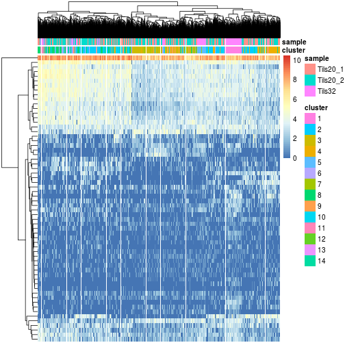

```r
library(pheatmap)
library(RColorBrewer)
library(viridis)

# select some top genes:
#top.markers <- rownames(marker.set)[marker.set$Top <= 100]
top.markers <- rownames(marker.set)[marker.set$Top <= 10]

# have matric to display
tmpData <- logcounts(nz.sce)[top.markers,]
tmpCellNames <- paste(colData(nz.sce)$Sample, colData(nz.sce)$Barcode, sep="_")
colnames(tmpData) <- tmpCellNames # colData(nz.sce)$Barcode

# columns annotation with cell name:
mat_col <- data.frame(cluster = nz.sce$cluster, sample = nz.sce$Sample)
rownames(mat_col) <- colnames(tmpData)
rownames(mat_col) <- tmpCellNames # colData(nz.sce)$Barcode

colourCount = length(unique(nz.sce$cluster))
getPalette = colorRampPalette(brewer.pal(9, "Set1"))

mat_colors <- list(group = getPalette(colourCount))
names(mat_colors$group) <- unique(nz.sce$cluster)

pheatmap(tmpData,
           border_color      = NA,
  show_colnames     = FALSE,
  show_rownames     = FALSE,
  drop_levels       = TRUE,
         annotation_col    = mat_col,
         annotation_colors = mat_colors
         )
```

```r
if(FALSE)
{
plotHeatmap(sce, features=top.markers, columns=order(sce$cluster),
    #colour_columns_by=c("cluster"),
    colour_columns_by=c("Sample"),
    #cluster_cols=FALSE, center=TRUE, symmetric=TRUE, zlim=c(-5, 5))
    cluster_cols=TRUE, center=TRUE, symmetric=TRUE, zlim=c(-5, 5))
}
if(FALSE)
{
top.markers10 <- rownames(marker.set)[marker.set$Top <= 10]
plotHeatmap(nz.sce, features=top.markers10, columns=order(my.clusters),
    #colour_columns_by="cluster", cluster_cols=FALSE,
    colour_columns_by="cluster", # cluster_cols=FALSE,
    center=TRUE, symmetric=TRUE, zlim=c(-5, 5))
}
```

One can sort both the gene and sample dendrograms to improve the heatmap.

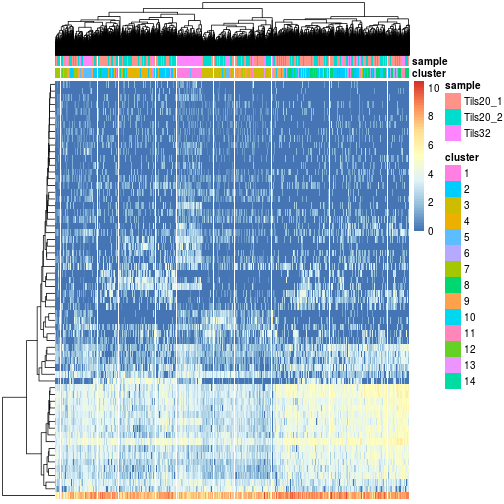

```r
library(dendsort)

mat <- tmpData
mat_cluster_cols <- hclust(dist(t(mat)))

sort_hclust <- function(...) as.hclust(dendsort(as.dendrogram(...)))

mat_cluster_cols <- sort_hclust(mat_cluster_cols)
#plot(mat_cluster_cols, main = "Sorted Dendrogram", xlab = "", sub = "")

mat_cluster_rows <- sort_hclust(hclust(dist(mat)))

pheatmap(tmpData,
           border_color      = NA,
  show_colnames     = FALSE,
  show_rownames     = FALSE,
  drop_levels       = TRUE,
         annotation_col    = mat_col,
         annotation_colors = mat_colors,
   cluster_cols      = mat_cluster_cols,
  cluster_rows      = mat_cluster_rows
         )
```

#### Challenges

Challenge? Compare t-SNE obtained here to that shown in the article and show expression level of reported markers genes on t-SNE plots.

Challenge? Identify genes that are upregulated in each cluster compared to others.

Challenge? Identify genes differentially expressed between a cluster and all others.

Challenge? Identify genes whose distribution of expression, rather than their average expression, differs between clusters (Hint: overlapExprs() may help).

Save object.

```r
rObjFile <- "Tcells_SCE_comb_session.RData"

# check file exists:
#tmpFileName <- file.path(inpDir, dataSubDir, rObjFile)
tmpFileName <- file.path(rObjFile)

# uncomment to save sesssion # save.image(file=tmpFileName)
```